Restarted 'Python 3.10.5 64-bit' kernel

# **About:**

This code covers the following concepts:

- **Binomial Distribution**
- **Continuous Uniform Distribution**
- **Normal Distribution**

# **Binomial Distribution**

# Problem statement

1. Find the probability that every visitor will end up buying souvenirs.
2. Find the probability that a maximum of 7 visitors will buy souvenirs from the souvenir shop

## Interpretation

The interpretation that 80% of all visitors will buy is translated to 80% chance that a single visitor will buy.

## Assumptions

1. There are only two possible outcomes for a given trial (success or failure) i.e., a visitor will buy a souvenir or not.
2. Number of trials is fixed - there are 10 repetitions or 10 visitors in the sample $(n=10)$.
3. Each trial is independent of the other trials.
4. The probability of success is the same for each trial $(p=0.8)$

# Libraries

```python
import pandas as pd
import numpy as np
import matplotlib.pyplot as plt
import seaborn as sns
# scipy library contains a large number of probability distributions, and continuously growing
import scipy.stats as stats
```

# Let's estimate the probability distribution of visitors

```python
# Declare the sample size - `n` representing the number of visitors selected randomly
n = 10
# Declare `p` which represents the probability of success (probability that a visitor will end up buying a souvenir or not)
p = 0.80
# Declare different possible number of visitors selected in a numpy array
k = np.arange(0,11)
k
```

```
array([ 0,  1,  2,  3,  4,  5,  6,  7,  8,  9, 10])
```

The probability function of Binomial Distribution provides the probability for $x$ number of successes from $n$ trials where $p$ is the probability of success

> $P(X=x)= {n\choose x}p^x(1-p)^{n-x}$ Here, we know that:
> - $n$ (number of visitors selected randomly) = 10
> - $p$ (probability of success i.e., the probability that a visitor will end up buying a souvenir) = 0.80
> - $q$ (probability of failure i.e., the probability that a visitor will not end up buying a souvenir) = 1 - 0.80 = 0.20
> - $x$ (number of successes) = 10  
>   We will use `binom.pmf()` to calculate this probability function which provides the probability for the number of visitors (out of $n=10$) that will end up buying souvenirs from the souvenir shop.

# Generate the probability distribution

```python
from scipy.stats import binom
binomial = binom.pmf(k=k, n=n, p=p)
binomial
```

```
array([1.02400000e-07, 4.09600000e-06, 7.37280000e-05, 7.86432000e-04,
       5.50502400e-03, 2.64241152e-02, 8.80803840e-02, 2.01326592e-01,
       3.01989888e-01, 2.68435456e-01, 1.07374182e-01])
```

# Notes

1. In the above output `binomial` is the array of probabilities for different number of successes.
2. For example the probability of having 0 success (or 0 person buys; k=0) is the first value of `binomial` array, the probability of having 1 success (k=1) is the second value of the `binomial` array.
3. The last element of this `binomial` array represents the probability when the number of successes is 10 (which means that all 10 visitors (out of 10 selected randomly) will buy souvenirs from the souvenir shop).

Plot the distribution

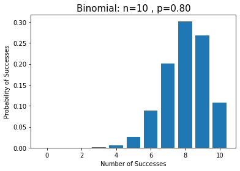

```python
plt.bar(k, binomial) # make a bar plot
plt.title("Binomial: n=%i , p=%.2f" % (n, p), fontsize=15) # set the title
plt.xlabel("Number of Successes") # set the x-axis label
plt.ylabel("Probability of Successes") # set the y-axis label
plt.show() # display the plot
```

# Notes

1. If we expect 80% of the people to buy a souvenir then the chance that exactly 8 out of 10 do buy a souvneir is about 30% or 0.3.
2. The above is the distribution of 6 people buying, 7 people buying, 8 people buying, etc. laid out as a bar chart.

# Ans. 1

if there is an 8 in 10 chance (80% chance) that every visitor buys a souvenir, and exactly 10 people visit the museum,then there is about an 11% chance that everybody will buy something from the souvenir shop.

# Notes

1. For answering the second question, we need to calculate the probability for $P(X<=7)$ i.e, accumulated probability or CDF.
2. **CDF** of a Random variable (X) is the probability that $X$ will take the value less than or equal to $x$. It is used to calculate the cumulative probability, and can be represented mathematically as below.

   > $F_X(x) = P(X\leq x)$

   In our case, Random Variable $(X)$ is the number of visitors who will buy souvenirs from the souvenir shop and we need to find $P(X\leq 7)$.

# Ans. 2

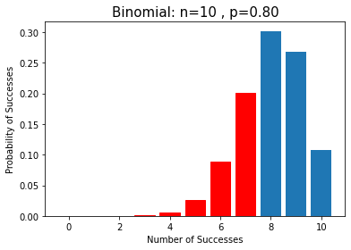

```python
barl = plt.bar(k, binomial)
plt.title("Binomial: n=%i , p=%.2f" % (n, p), fontsize=15) # set the title
plt.xlabel("Number of Successes") # set the x-axis label
plt.ylabel("Probability of Successes") # set the y-axis label
for i in range(0, 8):
    barl[i].set_color("r") # color the bars where no. of successes < 8
plt.show()
```

```python
binomial[:8].sum()
```

```
0.3222004735999996
```

```python
binom.cdf(k=7, n=n, p=p)
```

```
0.32220047359999987
```

# Notes

1. One interpretation of **Ans. 2** is in an year of sundays and every sunday 10 people come in, then roughly about 1/3rd of the sundays, we will get roughly about 7 or fewer people buying souvenirs.

# More usage of `cdf` function

If we wish to know the probability of having 'atleast x' no. of success, then it can be calculated using P(X>=x) 1 - cdf(x) as demonstrated below.

```python
# Probability of having ateast 4 success
1 - binom.cdf(k=3, n=n, p=p)
```

```
0.9991356416
```

# Change in distribution with `p`

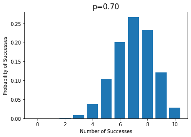

```python
# Probability distribution for p=0.7
binomial_70 = binom.pmf(k, n, p=0.7)
# Plot
plt.bar(k, binomial_70)
plt.title("p=%.2f" % (0.7), fontsize=15)
plt.xlabel("Number of Successes")
plt.ylabel("Probability of Successes")
```

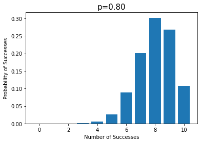

```python
# Probability distribution for p=0.8
binomial_80 = binom.pmf(k, n, p=0.8)
# Plot
plt.bar(k, binomial_80)
plt.title("p=%.2f" % (0.8), fontsize=15)
plt.xlabel("Number of Successes")
plt.ylabel("Probability of Successes")
```

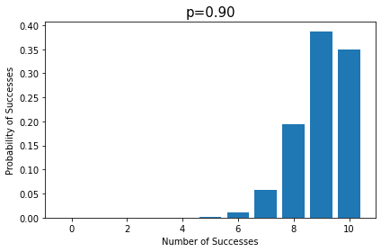

```python
# Probability distribution for p=0.9
binomial_90 = binom.pmf(k, n, p=0.9)
# Plot
plt.bar(k, binomial_90)
plt.title("p=%.2f" % (0.9), fontsize=15)
plt.xlabel("Number of Successes")
plt.ylabel("Probability of Successes")
plt.tight_layout(w_pad=5)
```

# Conclusion